# IE 582 - Statistical Learning for Data Mining Homework 1

The data seems to be ready for the imputation. Lets perform imputation with the function I have provided above!

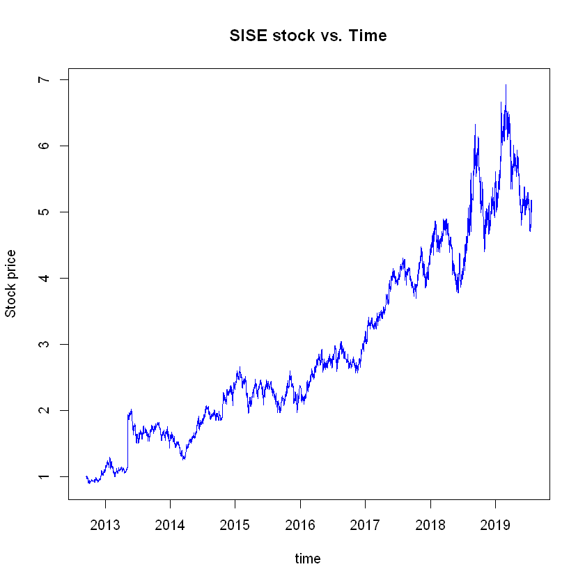

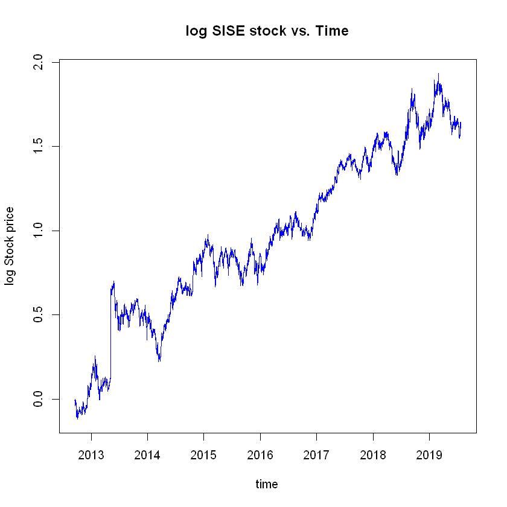

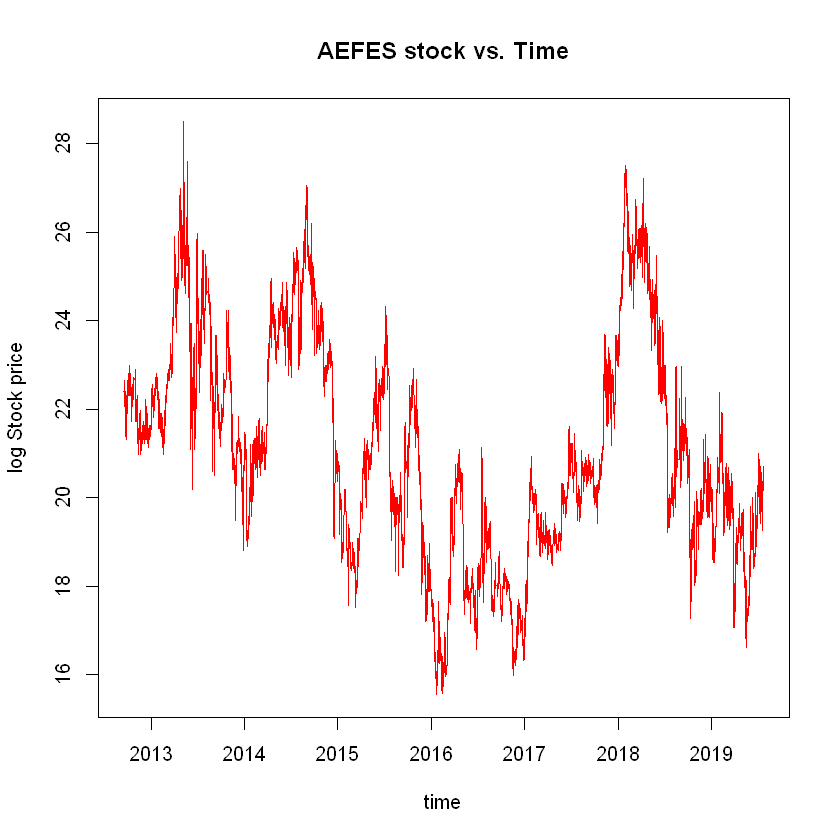

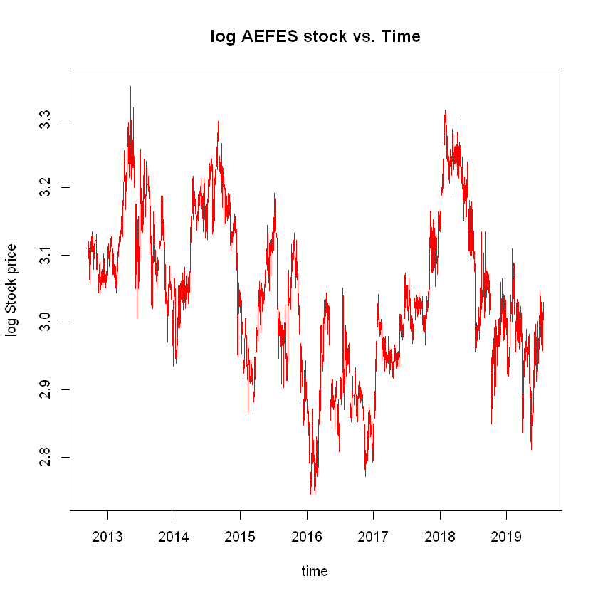

```r
datam <- matrix(0,nrow=6,ncol=50012)
datam[1,] <- 1:50012
datam[2,] <- data$AEFES
datam[3,] <- data$AYGAZ
datam[4,] <- data$TUPRS
datam[5,] <- data$SISE
datam[6,] <- data$ASELS
for(i in 2:6){
  datam[i,] <- filler(datam[i,],3)
}
plot(x=data$timestamp,y=datam[5,],type="l",col="blue",main="SISE stock vs. Time",xlab="time",ylab="Stock price")
plot(x=data$timestamp,y=log(datam[5,]),type="l",col="blue",main="log SISE stock vs. Time",xlab="time",ylab="log Stock price")
plot(x=data$timestamp,y=datam[2,],type="l",col="red",main="AEFES stock vs. Time",xlab="time",ylab="log Stock price")
plot(x=data$timestamp,y=log(datam[2,]),type="l",col="red",main="log AEFES stock vs. Time",xlab="time",ylab="log Stock price")
```

It can be observed that the data is not following the weak stationarity properties, that is the mean does not seem to be constant over time. There is a trend associated with time. Further, the variance does not seem to be constant over time, it is fluctuating with respect to time. At last, the covariance or correlation indices with respect to lags seems to be changing with respect to time. Thus, the data is not even weakly stationary. One might be doing log transformation at first to exclude the "possible" multiplier of the error term associated with time or another phenomenon. I have tried log transformations and it does make the series stationary with respect to its variance. However, there is also the trend information to consider if we would like to fixate the mean as well. A moving average approach may be applied to remove the trend but I will stop here.

3.03758651663819

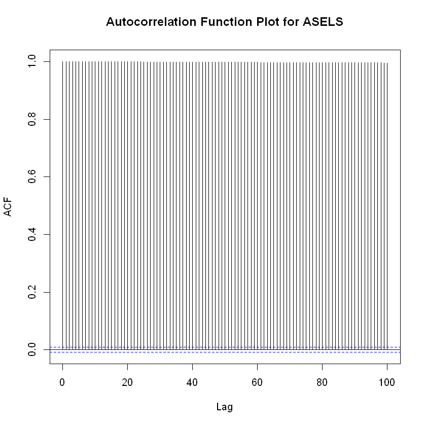

0.855438395597319

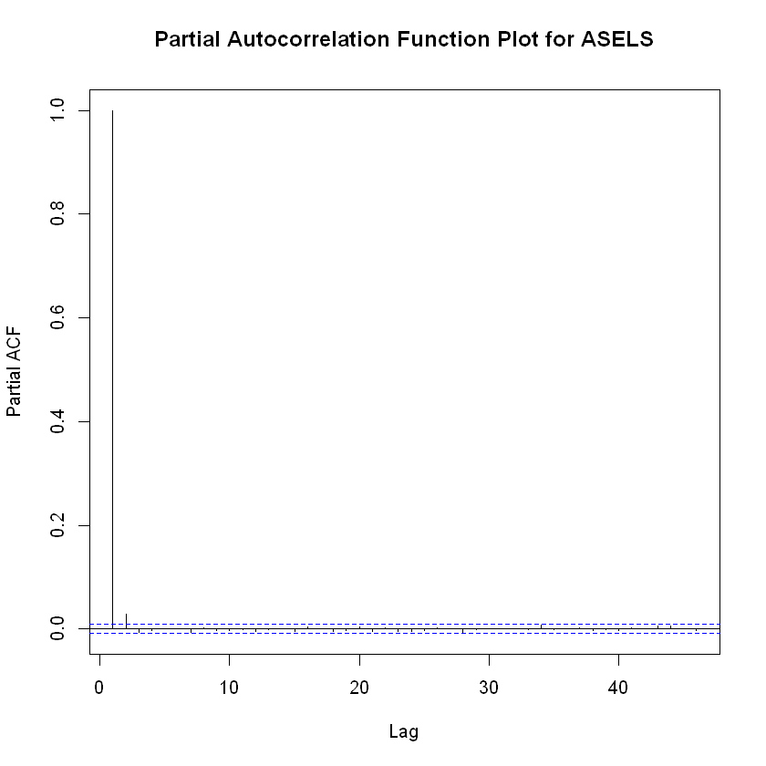

```
   Min. 1st Qu.  Median    Mean 3rd Qu.    Max.
  3.219   5.926   7.695   8.066  10.225  13.594
```

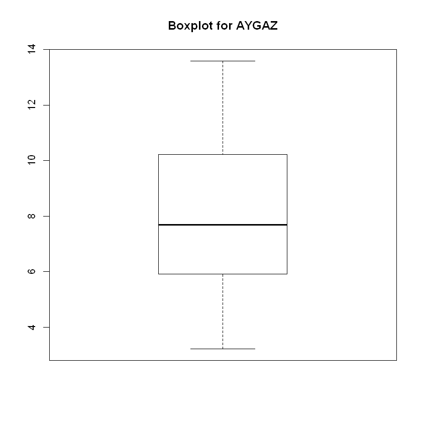

[figure not shown]

```r
mean(log(datam[2,]))
acf(log(datam[6,]),lag=100,main="Autocorrelation Function Plot for ASELS")
pacf(log(datam[6,]),main="Partial Autocorrelation Function Plot for ASELS")
cor(log(datam[3,]),log(datam[1,]))
boxplot(datam[3,],main="Boxplot for AYGAZ")
summary(datam[3,])
hist(datam[3,], xlab="ASELS stock prices",ylab="relative frequencies", main="ASELS Histogram")
```

0.244222529250502

```
      Min.    1st Qu.     Median       Mean    3rd Qu.       Max.
-0.1017924 -0.0013035  0.0000000  0.0000204  0.0013153  0.1497231
```

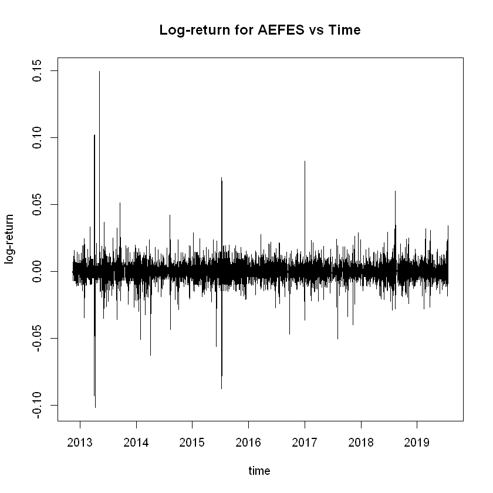

1. 0.00245488914042178

2. 0

3. -0.0024548891404218

4. 0

5. 0

6. 0.00245488914042178

1. 0.00101163387484423

2. -0.00506843457045873

3. 0.00506843457045873

4. 0

5. -0.0071030232682463

6. 0

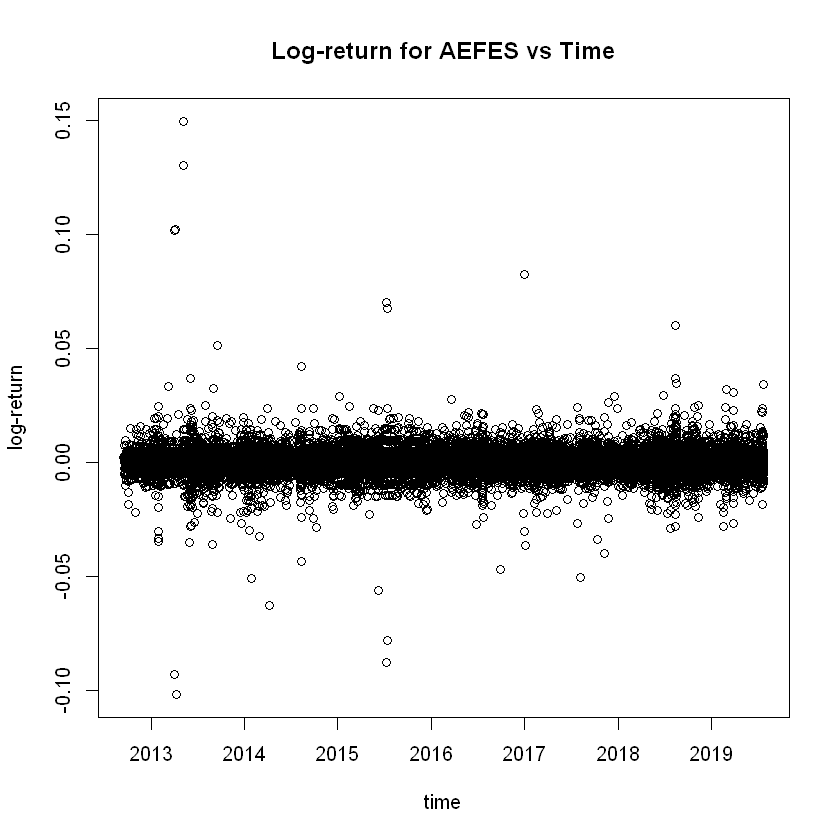

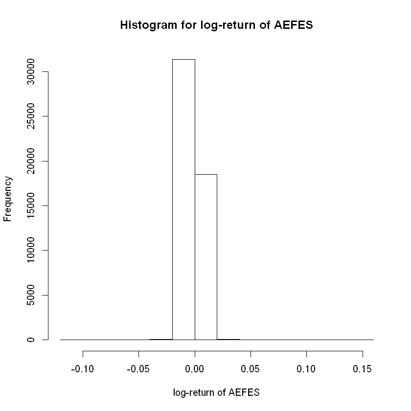

```r
datamlr <- matrix(0,nrow=5,ncol=50011)
k <- 1:50011
for(i in 1:5){
  datamlr[i,] <- log(datam[i+1,(k+1)]/datam[i+1,k])
}
plot(y=datamlr[2,1000:50011],x=data$timestamp[1000:50011],type="l",main="Log-return for AEFES vs Time",xlab="time",ylab="log-return")
cor(datamlr[2,],datamlr[4,])
summary(datamlr[2,])
plot(datamlr[2,],x=data$timestamp[-1],main="Log-return for AEFES vs Time",xlab="time",ylab="log-return")
head(datamlr[2,])
tail(datamlr[2,])
hist(datamlr[2,],breaks=10,main="Histogram for log-return of AEFES",xlab="log-return of AEFES")
```

I have also tried the log-return approach that follows from log(Y_t+1/Y_t) or log(Y_t+1)-log(Y_t). The returns have somewhat stationarized but the variance and outliers still seem to be existing in high numbers. This phenomenon may be caused by the week ending-openings of the stock prices. Also, each day the market is closed and opened again. Therefore, a further examination of political tensions might explain the phenomenon.

```r
pca_obj = princomp(t(datamlr),cor=T) #performing PCA on log-returns
summary(pca_obj,loadings=T)

pca_obj = princomp(t(datam[2:6,]),cor=T) #performing PCA on raw prices
summary(pca_obj,loadings=T)
```

```
Importance of components:
                          Comp.1    Comp.2    Comp.3    Comp.4    Comp.5
Standard deviation     1.3334173 0.9450318 0.9092008 0.8815100 0.8515910
Proportion of Variance 0.3556004 0.1786170 0.1653292 0.1554120 0.1450414
Cumulative Proportion  0.3556004 0.5342174 0.6995466 0.8549586 1.0000000

Loadings:
     Comp.1 Comp.2 Comp.3 Comp.4 Comp.5
[1,]  0.351  0.927         0.110
[2,]  0.442 -0.245  0.722  0.350  0.317
[3,]  0.480 -0.134 -0.206 -0.699  0.470
[4,]  0.506 -0.101  0.123 -0.220 -0.819
[5,]  0.443 -0.231 -0.649  0.573
```

```
Importance of components:
                          Comp.1    Comp.2     Comp.3     Comp.4     Comp.5
Standard deviation     1.9156454 1.0073657 0.47724560 0.25014968 0.15867861
Proportion of Variance 0.7339394 0.2029571 0.04555267 0.01251497 0.00503578
Cumulative Proportion  0.7339394 0.9368966 0.98244925 0.99496422 1.00000000

Loadings:
     Comp.1 Comp.2 Comp.3 Comp.4 Comp.5
[1,]         0.986  0.117  0.105
[2,] -0.489        -0.683  0.425  0.333
[3,] -0.501         0.528 -0.230  0.645
[4,] -0.504         0.413  0.521 -0.547
[5,] -0.503  0.140 -0.265 -0.695 -0.416
```